# Week 10 - Day 01 Homework

```r
library(tidyverse)
library(modelr)
library(broom)
library(ggfortify)
```

Simple linear regression homework

## MVP

The file project_management.csv contains data sampled from the recent work schedule of a small construction company. Column estimated_length contains the estimated length of a building job in days, while column actual_length contains the actual recorded length of the job in days.

We are interested in determining the accuracy of the job estimations made by the company using simple linear regression, so we will eventually want to run a simple linear regression using actual_length as the dependent/response/outcome variable, and estimated_length as the independent/predictor/explanatory variable.

1. Load the data into a dataframe `project`

```r
project <- read_csv("data/project_management.csv")
```

2. Plot the data, taking `estimated_length` as the independent variable and `actual_length` as the dependent variable.

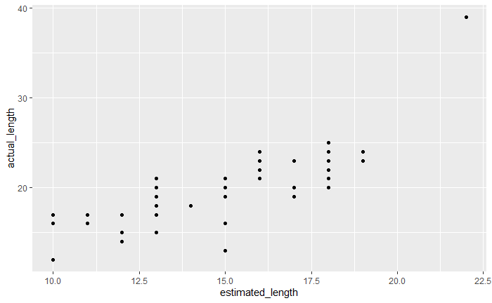

```r
project %>%
  ggplot(aes(x = estimated_length, y = actual_length)) +
  geom_point()
```

3. Calculate the correlation coefficient of `estimated_length` and `actual_length` and interpret the value you obtain.

```r
project %>%
  summarise(correlation_coef = cor(estimated_length, actual_length))
```

| correlation_coef |
| --- |
| 0.8046597 |

This value tells us that there is a strong positive correlation between estimated_length and actual_length - as one goes up, so does the other

4. Perform a simple linear regression using `actual_length` as the dependent variable, and `estimated_length` as the independent variable. Save the model object to a variable.

```r
(project_model <- lm(
  formula = actual_length ~ estimated_length,
  data = project
))
```

```
Call:
lm(formula = actual_length ~ estimated_length, data = project)

Coefficients:
     (Intercept)  estimated_length
           1.416             1.223
```

5. Interpret the regression coefficient of estimated_length (i.e. slope, gradient) you obtain from the model. How do you interpret the r^2 value reported by the model?

```r
tidy(project_model)
```

| term | estimate | std.error | statistic | p.value |
| --- | --- | --- | --- | --- |
| (Intercept) | 1.416379 | 2.0069491 | 0.7057375 | 4.837627e-01 |
| estimated_length | 1.223489 | 0.1303049 | 9.3894314 | 1.911284e-12 |

In this model, a 1 day increase in estimated_length increases the value of actual_length by approx 1.22 days

```r
glance(project_model)
```

| r.squared | adj.r.squared | sigma | statistic | p.value | df | logLik | AIC | BIC | deviance | df.residual | nobs |
| --- | --- | --- | --- | --- | --- | --- | --- | --- | --- | --- | --- |
| 0.6474772 | 0.640133 | 2.606163 | 88.16142 | 1.911284e-12 | 1 | -117.8203 | 241.6407 | 247.3767 | 326.0201 | 48 | 50 |

Around 65% of the variation in actual_length can be predicted by the variation in estimated_length - This tells us that the line is not a particularly good fit

6. Is the relationship statistically significant? Remember, to assess this you need to check the p-value of the regression coefficient (or slope/gradient). But you should first check the regression diagnostic plots to see if the p-value will be reliable

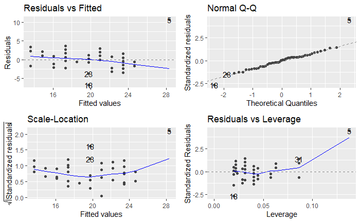

```r
autoplot(project_model)
```

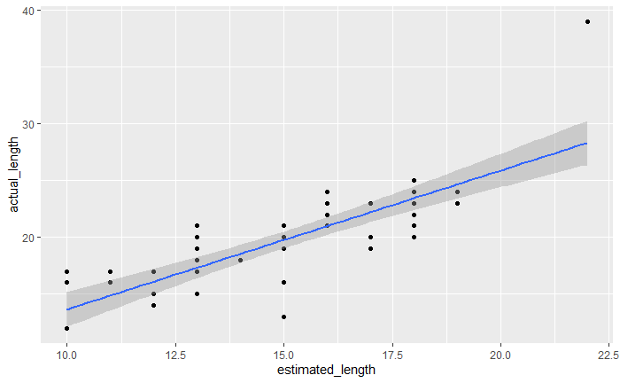

```r
project %>%
  ggplot(aes(x = estimated_length, y = actual_length)) +
  geom_point() +
  geom_smooth(method = "lm")
```

```r
glance(project_model) %>%
  select(p.value) %>%
  pull()
```

[output not shown]

If we assume: a significance level of 0.05 H-Null to be “the coefficient makes no statistically significant difference to the model” H-Alt to be “the coefficient makes statistically significant difference to the model”

Given a p-value of 1.911284e-12, which is below the significance level of 0.05, we can reject our null hypothesis in favour of our alternative hypothesis, that the relationship is statistically significant to the model

## Extension - Residuals vs Leverage

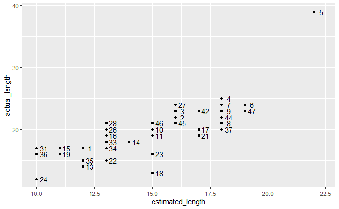

```r
project %>%
  ggplot(aes(x = estimated_length, y = actual_length)) +
  geom_point()+
  geom_text(aes(label = 1:nrow(project)), colour = "black", nudge_x = 0.3, check_overlap = TRUE)
```

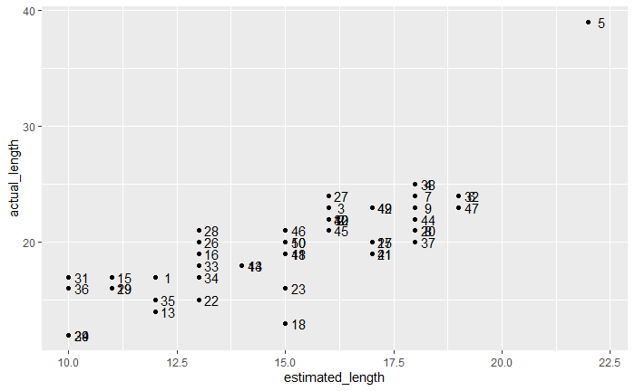

```r
project %>%
  ggplot(aes(x = estimated_length, y = actual_length)) +
  geom_point()+
  geom_text(aes(label = 1:nrow(project)), colour = "black", nudge_x = 0.3, check_overlap = FALSE)
```

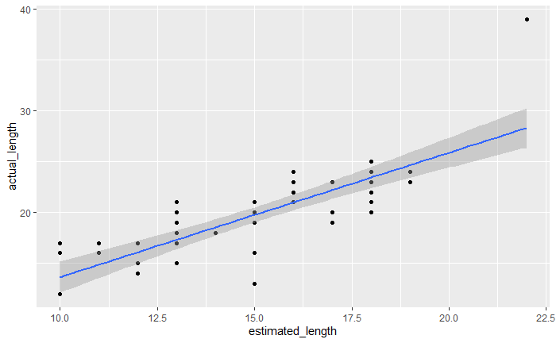

```r
project %>%
  ggplot(aes(x = estimated_length, y = actual_length)) +
  geom_point() +
  geom_smooth(method = "lm")
```

Points 5, 18, 24 (and all points ontop of it), 28, 26, 16, 37

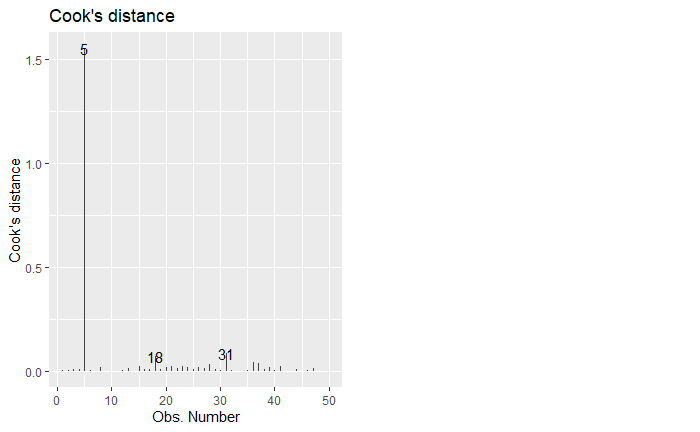

```r
autoplot(project_model, which = 4)

par(mfrow = c(2,2))
```

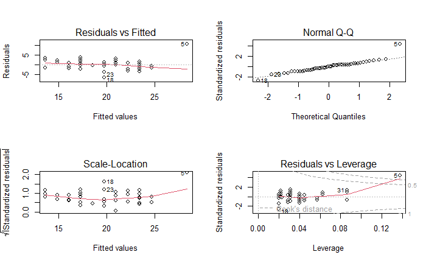

```r
plot(project_model)
```

```r
project_28_omitted <- project %>%
  filter(...1 != 28)
```

```r
(project_model_28_omitted <- lm(
  formula = actual_length ~ estimated_length,
  data = project_28_omitted
))
```

```
Call:
lm(formula = actual_length ~ estimated_length, data = project_28_omitted)

Coefficients:
     (Intercept)  estimated_length
           1.033             1.244
```

```r
project_model
```

```
Call:
lm(formula = actual_length ~ estimated_length, data = project)

Coefficients:
     (Intercept)  estimated_length
           1.416             1.223
```

[figure not shown]

Omitting an influential point

```r
project_5_omitted <- project %>%
  filter(...1 != 5)
```

```r
(project_model_5_omitted <- lm(
  formula = actual_length ~ estimated_length,
  data = project_5_omitted
))
```

```
Call:
lm(formula = actual_length ~ estimated_length, data = project_5_omitted)

Coefficients:
     (Intercept)  estimated_length
           4.381             1.011
```

```r
project_model
```

```
Call:
lm(formula = actual_length ~ estimated_length, data = project)

Coefficients:
     (Intercept)  estimated_length
           1.416             1.223
```

There appear to be pretty major differences in the Intercept and the slope

[figure not shown]

The lines have shifted quite a bit here - It is shorter, and at a shallower angle

checking 18

```r
project_18_omitted <- project %>%
  filter(...1 != 18)
```

```r
(project_model_18_omitted <- lm(
  formula = actual_length ~ estimated_length,
  data = project_18_omitted
))
```

```
Call:
lm(formula = actual_length ~ estimated_length, data = project_18_omitted)

Coefficients:
     (Intercept)  estimated_length
           1.591             1.221
```

```r
project_model
```

```
Call:
lm(formula = actual_length ~ estimated_length, data = project)

Coefficients:
     (Intercept)  estimated_length
           1.416             1.223
```

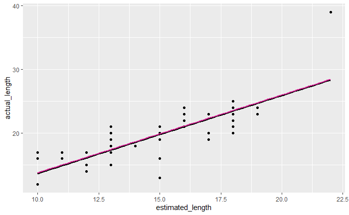

```r
graph_project +
  geom_smooth(data = project_18_omitted, method = "lm", se = FALSE, colour = "violetred")
```

No major difference here